### Instalação da researchpy

```python
!pip install researchpy
```

# Importação das bibliotecas

```python
import numpy as np
import pandas as pd
import matplotlib.pyplot as plt
import seaborn as sb
import statsmodels.api as sm
import researchpy
import pydotplus
from scipy import stats
from scipy.stats import chi2_contingency
from scipy.stats import chi2
from sklearn.linear_model import LinearRegression
from sklearn.model_selection import train_test_split
from sklearn.metrics import mean_absolute_error, mean_squared_error
from sklearn.tree import DecisionTreeClassifier,export_graphviz
from sklearn.tree import plot_tree
from sklearn.metrics import accuracy_score, classification_report
```

# Obtendo a base

Como foi utilizado o Google Colab você precisa importar a base: Arquivo_Salarios_Colaboradores_2021.csv

Para realizar isso segue um tutorial:

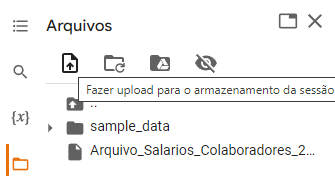

**Feito isso podemos então ler os dados a seguir:**

# Obtendo os dados e lendo o arquivo:

```python
salarios = pd.read_csv(r'Arquivo_Salarios_Colaboradores_2021.csv', sep=';')
```

## Verificando como os dados estão:

```python
salarios.head()
```

|  | Ordem | salario | idade | tempocasa | escolar | qproj_estra | proj_sustent | proj_6sigma | proj_social | notaavalia |
| --- | --- | --- | --- | --- | --- | --- | --- | --- | --- | --- |
| 0 | 1 | 8000.80 | 25 | 4 | 11 | 1 | 1 | 1 | 0 | 79.38 |
| 1 | 2 | 8500.17 | 24 | 5 | 11 | 0 | 0 | 1 | 0 | 84.13 |
| 2 | 3 | 3350.59 | 22 | 1 | 12 | 0 | 0 | 0 | 0 | 46.15 |
| 3 | 4 | 9500.24 | 28 | 4 | 14 | 1 | 0 | 0 | 1 | 83.85 |
| 4 | 5 | 1500.63 | 18 | 2 | 12 | 0 | 0 | 0 | 1 | 73.64 |

### Interpretação dos dados

Essa base indica que foi dada uma nota de avaliação para funcionários que possuem os dados de:

- Ordem que aparenta ser uma avaliação do funcionário para ordenar ele na empresa
- Sálario
- Idade do funcionário
- O tempo que ele trabalha na empresa
- O total de tempo de estudo
- Se o funcionário participou de projetos estratégicos
- Se o funcionário participou de projetos sustentáveis
- Pontuação do funcionários em projetos 6 sigma
- Se o funcionário participou de projetos sociais
- Aparenta que a nota do funcionário está baseada no critério de projetos e tempo que trabalha na empresa.

### Visualizando os dados que foram importados

```python
salarios.info()
```

```
<class 'pandas.core.frame.DataFrame'>
RangeIndex: 180 entries, 0 to 179
Data columns (total 10 columns):
 #   Column        Non-Null Count  Dtype
---  ------        --------------  -----
 0   Ordem         180 non-null    int64
 1   salario       180 non-null    float64
 2   idade         180 non-null    int64
 3   tempocasa     180 non-null    int64
 4   escolar       180 non-null    int64
 5   qproj_estra   180 non-null    int64
 6   proj_sustent  180 non-null    int64
 7   proj_6sigma   180 non-null    int64
 8   proj_social   180 non-null    int64
 9   notaavalia    180 non-null    float64
dtypes: float64(2), int64(8)
memory usage: 14.2 KB
```

### Verificar o total e a proporção de null na base

```python
salarios.isnull() # Aqui verificamos o total de null na base se existir
salarios.isnull().sum()/len(salarios) # Aqui obtemos a proporção de null se existir

# Criamos um novo DataFrame para verificar o total e a proporção de null na base
pd.DataFrame(zip(salarios.isnull().sum(),salarios.isnull().sum()/len(salarios)), columns=['Count', 'Proportion'], index=salarios.columns)
```

|  | Count | Proportion |
| --- | --- | --- |
| Ordem | 0 | 0.0 |
| salario | 0 | 0.0 |
| idade | 0 | 0.0 |
| tempocasa | 0 | 0.0 |
| escolar | 0 | 0.0 |
| qproj_estra | 0 | 0.0 |
| proj_sustent | 0 | 0.0 |
| proj_6sigma | 0 | 0.0 |
| proj_social | 0 | 0.0 |
| notaavalia | 0 | 0.0 |

### Aqui realizamos uma análise descritiva dos dados e arredondamos o valor com 2 casas decimais.

Após essa análise conseguimos chegar a algumas percepções dos dados:

- A média de salário da base é de: **8539.49**
- O desvio padrão é de: **4729.51**
- O menor sálario da base é de: **1500.63**
- Meu percentil de 25% na base de salários é de: **5491.23** neste caso podemos avaliar que possuímos uma média de salários mencionada anteriormente.
- Meu percentil de 50% na base de salários é de: **7551.12** neste caso podemos avaliar que possuímos uma média de salários mencionada anteriormente.
- Meu percentil de 75% na base de salários é de: **10584.68** neste caso podemos avaliar que possuímos uma média de salários mencionada anteriormente.
- O maior sálario da base é de: **25329.91**

```python
# descritivo das variáveis: medidas resumo
salarios.describe().round(2).T
```

|  | count | mean | std | min | 25% | 50% | 75% | max |
| --- | --- | --- | --- | --- | --- | --- | --- | --- |
| Ordem | 180.0 | 90.50 | 52.11 | 1.00 | 45.75 | 90.50 | 135.25 | 180.00 |
| salario | 180.0 | 8539.49 | 4729.51 | 1500.63 | 5491.23 | 7551.12 | 10584.68 | 25329.91 |
| idade | 180.0 | 31.07 | 9.35 | 18.00 | 24.00 | 28.00 | 36.00 | 65.00 |
| tempocasa | 180.0 | 9.07 | 5.61 | 1.00 | 5.00 | 7.00 | 13.00 | 25.00 |
| escolar | 180.0 | 12.58 | 2.57 | 7.00 | 11.00 | 13.00 | 14.00 | 19.00 |
| qproj_estra | 180.0 | 1.27 | 1.22 | 0.00 | 1.00 | 1.00 | 1.00 | 7.00 |
| proj_sustent | 180.0 | 0.28 | 0.45 | 0.00 | 0.00 | 0.00 | 1.00 | 1.00 |
| proj_6sigma | 180.0 | 0.55 | 0.50 | 0.00 | 0.00 | 1.00 | 1.00 | 1.00 |
| proj_social | 180.0 | 0.50 | 0.50 | 0.00 | 0.00 | 0.50 | 1.00 | 1.00 |
| notaavalia | 180.0 | 71.74 | 15.99 | 34.48 | 60.41 | 72.08 | 83.85 | 98.96 |

### Histograma da variável Sálario

Aqui vemos a frequência do salário e ao analisar o histograma parcebemos que existe realmente uma frequência de salários entre **5000** à **10.000**.

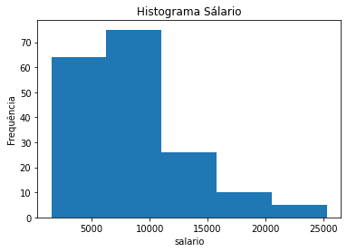

```python
plt.hist(salarios['salario'], bins=5)
plt.ylabel('Frequência')
plt.xlabel('salario')
plt.title('Histograma Sálario')
```

### Verificar as distribuição das variáveis númericas:

- salario
- idade
- tempocasa
- escolar
- qproj_estra
- proj_sustent
- proj_6sigma
- proj_social
- notaavalia

Fizemos isso para verificar o peso das variáveis.

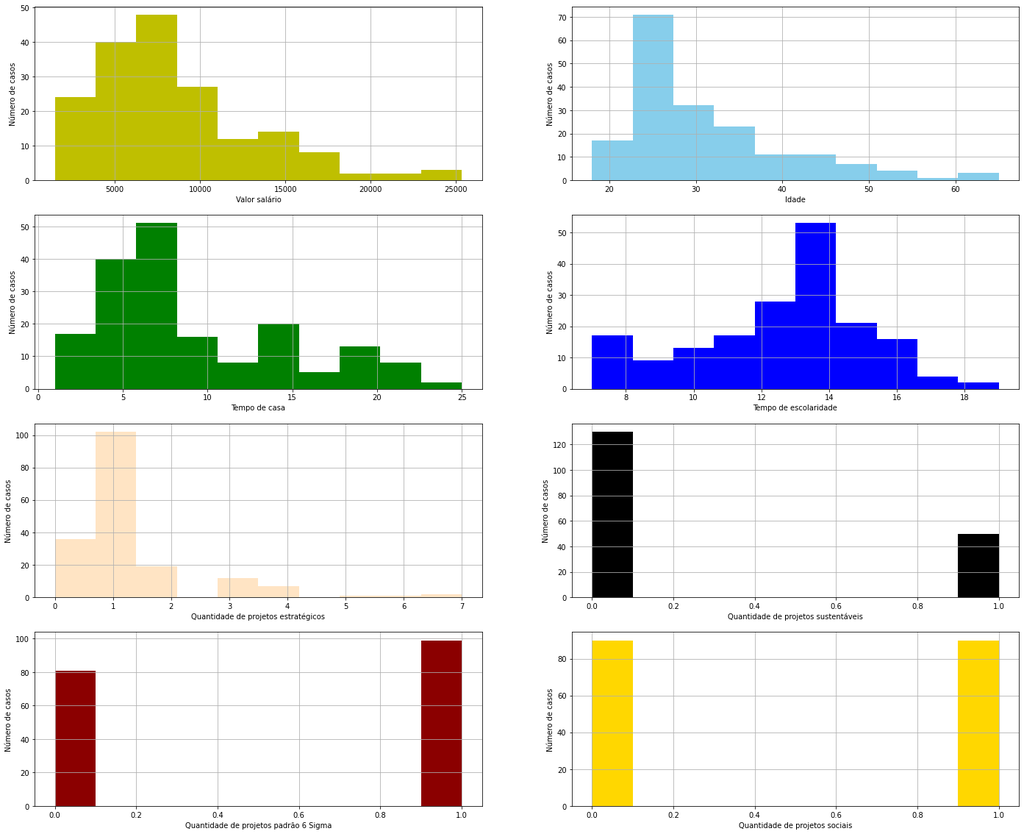

```python
plt.figure(figsize=(24,20))

plt.subplot(4, 2, 1)
fig = salarios['salario'].hist(color='y')
fig.set_xlabel('Valor salário')
fig.set_ylabel('Número de casos')

plt.subplot(4, 2, 2)
fig = salarios['idade'].hist(color='skyblue')
fig.set_xlabel('Idade')
fig.set_ylabel('Número de casos')

plt.subplot(4, 2, 3)
fig = salarios['tempocasa'].hist(color='g')
fig.set_xlabel('Tempo de casa')
fig.set_ylabel('Número de casos')

plt.subplot(4, 2, 4)
fig = salarios['escolar'].hist(color='b')
fig.set_xlabel('Tempo de escolaridade')
fig.set_ylabel('Número de casos')

plt.subplot(4, 2, 5)
fig = salarios['qproj_estra'].hist(color='bisque')
fig.set_xlabel('Quantidade de projetos estratégicos')
fig.set_ylabel('Número de casos')

plt.subplot(4, 2, 6)
fig = salarios['proj_sustent'].hist(color='black')
fig.set_xlabel('Quantidade de projetos sustentáveis')
fig.set_ylabel('Número de casos')

plt.subplot(4, 2, 7)
fig = salarios['proj_6sigma'].hist(color='darkred')
fig.set_xlabel('Quantidade de projetos padrão 6 Sigma')
fig.set_ylabel('Número de casos')

plt.subplot(4, 2, 8)
fig = salarios['proj_social'].hist(color='gold')
fig.set_xlabel('Quantidade de projetos sociais')
fig.set_ylabel('Número de casos')

plt.show()
```

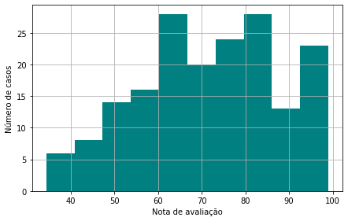

```python
plt.figure(figsize=(24,20))

plt.subplot(4,3,11)
fig = salarios['notaavalia'].hist(color='teal')
fig.set_xlabel('Nota de avaliação')
fig.set_ylabel('Número de casos')

plt.show()
```

### Criação dos gráficos de Boxplot

Criamos os gráficos a seguir para verificar os Outliers da nossa base com as variáveis:

- salario
- idade
- tempocasa
- escolar
- qproj_estra
- proj_sustent
- proj_6sigma
- proj_social
- notaavalia

Baseado no peso das variáveis nos escolhemos verificar as variáveis anteriores.

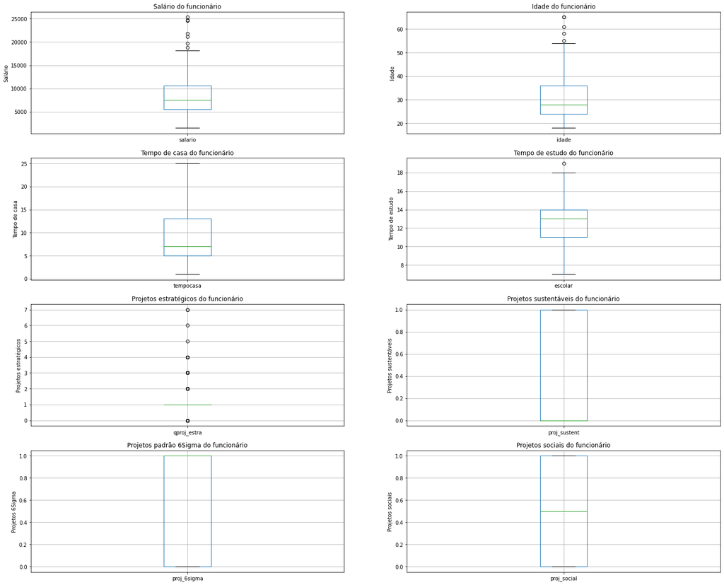

```python
plt.figure(figsize=(24,20))

plt.subplot(4, 2, 1)
fig = salarios.boxplot(column='salario')
fig.set_title('Salário do funcionário')
fig.set_ylabel('Salário')

plt.subplot(4, 2, 2)
fig = salarios.boxplot(column='idade')
fig.set_title('Idade do funcionário')
fig.set_ylabel('Idade')

plt.subplot(4, 2, 3)
fig = salarios.boxplot(column='tempocasa')
fig.set_title('Tempo de casa do funcionário')
fig.set_ylabel('Tempo de casa')

plt.subplot(4, 2, 4)
fig = salarios.boxplot(column='escolar')
fig.set_title('Tempo de estudo do funcionário')
fig.set_ylabel('Tempo de estudo')

plt.subplot(4, 2, 5)
fig = salarios.boxplot(column='qproj_estra')
fig.set_title('Projetos estratégicos do funcionário')
fig.set_ylabel('Projetos estratégicos')

plt.subplot(4, 2, 6)
fig = salarios.boxplot(column='proj_sustent')
fig.set_title('Projetos sustentáveis do funcionário')
fig.set_ylabel('Projetos sustentáveis')

plt.subplot(4, 2, 7)
fig = salarios.boxplot(column='proj_6sigma')
fig.set_title('Projetos padrão 6Sigma do funcionário')
fig.set_ylabel('Projetos 6Sigma')

plt.subplot(4, 2, 8)
fig = salarios.boxplot(column='proj_social')
fig.set_title('Projetos sociais do funcionário')
fig.set_ylabel('Projetos sociais')

plt.show()
```

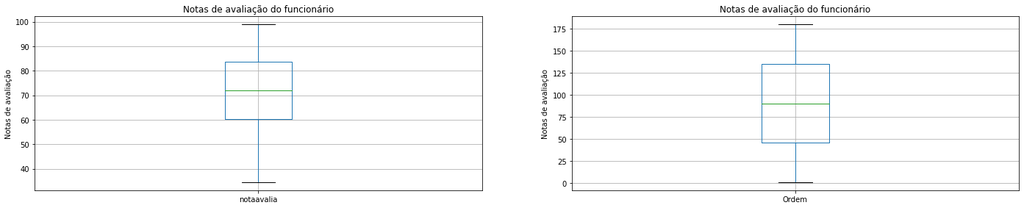

```python
plt.figure(figsize=(24,20))

plt.subplot(4, 2, 1)
fig = salarios.boxplot(column='notaavalia')
fig.set_title('Notas de avaliação do funcionário')
fig.set_ylabel('Notas de avaliação')

plt.subplot(4, 2, 2)
fig = salarios.boxplot(column='Ordem')
fig.set_title('Notas de avaliação do funcionário')
fig.set_ylabel('Notas de avaliação')

plt.show()
```

### Análise para remoção de coluna

Até este ponto da análise acreditamos que essas colunas não serão necessárias:

- proj_sustent
- proj_6sigma
- proj_social

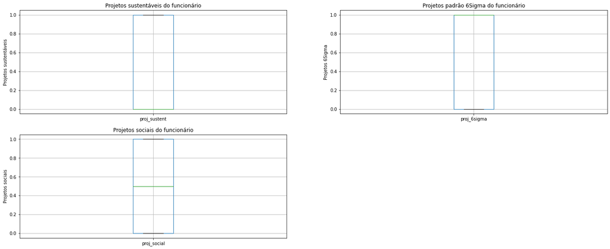

```python
plt.figure(figsize=(24,20))

plt.subplot(4, 2, 1)
fig = salarios.boxplot(column='proj_sustent')
fig.set_title('Projetos sustentáveis do funcionário')
fig.set_ylabel('Projetos sustentáveis')

plt.subplot(4, 2, 2)
fig = salarios.boxplot(column='proj_6sigma')
fig.set_title('Projetos padrão 6Sigma do funcionário')
fig.set_ylabel('Projetos 6Sigma')

plt.subplot(4, 2, 3)
fig = salarios.boxplot(column='proj_social')
fig.set_title('Projetos sociais do funcionário')
fig.set_ylabel('Projetos sociais')


plt.show()
```

# Remoção da coluna para correlação

A seguir nos removemos a coluna de ordem, pois acreditamos que ela não seja necessária para o cálculo de correlação:

- Ordem

Colocamos em uma nova base para que não perca a original caso precise re-avaliar algo.

```python
salariosBase = salarios.drop(['Ordem'], axis=1)
```

```python
salariosBase.head(5)
```

|  | salario | idade | tempocasa | escolar | qproj_estra | proj_sustent | proj_6sigma | proj_social | notaavalia |
| --- | --- | --- | --- | --- | --- | --- | --- | --- | --- |
| 0 | 8000.80 | 25 | 4 | 11 | 1 | 1 | 1 | 0 | 79.38 |
| 1 | 8500.17 | 24 | 5 | 11 | 0 | 0 | 1 | 0 | 84.13 |
| 2 | 3350.59 | 22 | 1 | 12 | 0 | 0 | 0 | 0 | 46.15 |
| 3 | 9500.24 | 28 | 4 | 14 | 1 | 0 | 0 | 1 | 83.85 |
| 4 | 1500.63 | 18 | 2 | 12 | 0 | 0 | 0 | 1 | 73.64 |

```python
salarios.head(5)
```

|  | Ordem | salario | idade | tempocasa | escolar | qproj_estra | proj_sustent | proj_6sigma | proj_social | notaavalia |
| --- | --- | --- | --- | --- | --- | --- | --- | --- | --- | --- |
| 0 | 1 | 8000.80 | 25 | 4 | 11 | 1 | 1 | 1 | 0 | 79.38 |
| 1 | 2 | 8500.17 | 24 | 5 | 11 | 0 | 0 | 1 | 0 | 84.13 |
| 2 | 3 | 3350.59 | 22 | 1 | 12 | 0 | 0 | 0 | 0 | 46.15 |
| 3 | 4 | 9500.24 | 28 | 4 | 14 | 1 | 0 | 0 | 1 | 83.85 |
| 4 | 5 | 1500.63 | 18 | 2 | 12 | 0 | 0 | 0 | 1 | 73.64 |

### Execução do coeficiente de correlação

Nós iremos utilizar o método de correlação de person, esse coeficiente é um teste que mede a relação estatística entre duas variáveis contínuas. Se a associação entre os elementos não for linear, o coeficiente não será representado adequadamente.

Resultado do coeficiente:

- **ρ = 0,9 a 1** (positivo ou negativo): correlação muito forte.
- **ρ = 0,7 a 0,9** (positivo ou negativo): correlação forte.
- **ρ = 0,5 a 0,7** (positivo ou negativo): correlação moderada.
- **ρ = 0,3 a 0,5** (positivo ou negativo): correlação fraca.
- **ρ = 0 a 0,3** (positivo ou negativo): não possui correlação.

```python
corr = salariosBase.corr(method='pearson')
corr
```

|  | salario | idade | tempocasa | escolar | qproj_estra | proj_sustent | proj_6sigma | proj_social | notaavalia |
| --- | --- | --- | --- | --- | --- | --- | --- | --- | --- |
| salario | 1.000000 | 0.600277 | 0.332923 | 0.492168 | 0.518249 | -0.017883 | 0.359549 | 0.237473 | 0.078258 |
| idade | 0.600277 | 1.000000 | 0.212797 | 0.299943 | 0.488883 | -0.103279 | 0.161561 | -0.000596 | 0.039255 |
| tempocasa | 0.332923 | 0.212797 | 1.000000 | -0.058369 | 0.087035 | -0.039051 | 0.115490 | -0.032775 | 0.069828 |
| escolar | 0.492168 | 0.299943 | -0.058369 | 1.000000 | 0.297009 | -0.102464 | 0.153629 | 0.175625 | -0.059922 |
| qproj_estra | 0.518249 | 0.488883 | 0.087035 | 0.297009 | 1.000000 | -0.057288 | 0.248645 | 0.260660 | 0.093075 |
| proj_sustent | -0.017883 | -0.103279 | -0.039051 | -0.102464 | -0.057288 | 1.000000 | -0.062330 | 0.248069 | 0.051128 |
| proj_6sigma | 0.359549 | 0.161561 | 0.115490 | 0.153629 | 0.248645 | -0.062330 | 1.000000 | 0.055835 | 0.069299 |
| proj_social | 0.237473 | -0.000596 | -0.032775 | 0.175625 | 0.260660 | 0.248069 | 0.055835 | 1.000000 | 0.115789 |
| notaavalia | 0.078258 | 0.039255 | 0.069828 | -0.059922 | 0.093075 | 0.051128 | 0.069299 | 0.115789 | 1.000000 |

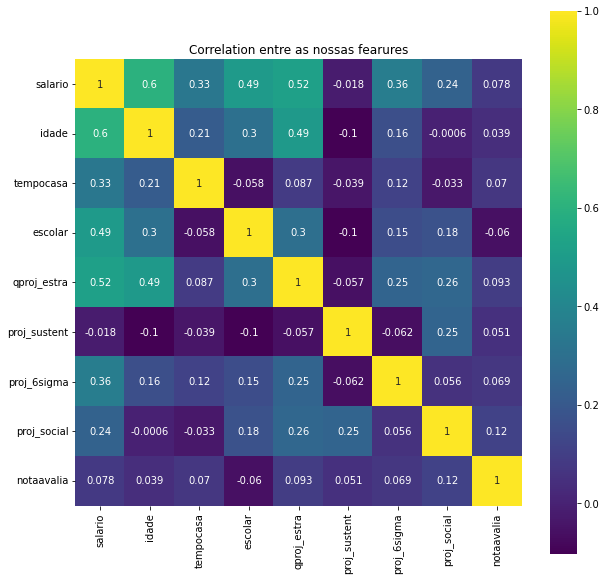

```python
correlation = salariosBase.corr()
plt.figure(figsize=(10,10))
sb.heatmap(correlation, vmax=1, square=True,annot=True,cmap='viridis')

plt.title('Correlation entre as nossas fearures')

plt.show()
```

### Realização da análise descritiva

Nossa variável target é salário, sendo assim realizamos um scatter plot do salário x a idade para verificar a relação de peso da idade do funcionário com o salário.

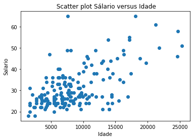

```python
plt.scatter('salario', 'idade', data=salariosBase)
plt.xlabel("Idade")
plt.ylabel("Salario")
plt.title(" Scatter plot Sálario versus Idade")
```

### Análise das variáveis preditoras/independentes

Realizamos uma análise das outras variáveis x a nossa variável target, essa análise foi feita nas variáveis:

- salario x tempocasa
- salario x escolar
- salario x qproj_estra
- salario x proj_sustent
- salario x proj_6sigma
- salario x proj_social
- salario x notaavalia

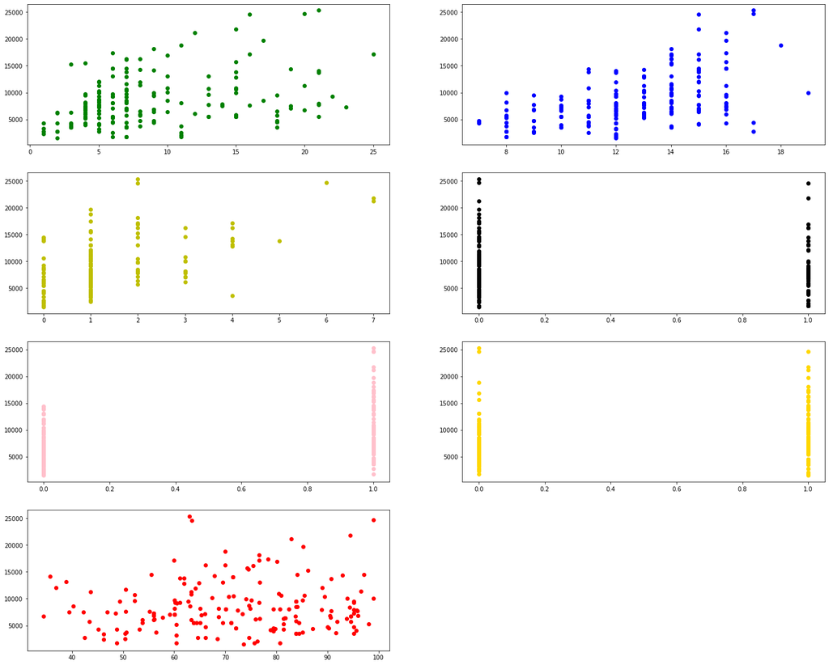

```python
plt.figure(figsize=(24,20))


plt.subplot(4, 2, 1)
plt.scatter(salariosBase['tempocasa'], salariosBase['salario'], marker='o', color='g');
fig.set_title('Análise sálario x tempo de casa')
fig.set_ylabel('Sálario')
fig.set_xlabel('Tempo de casa')

plt.subplot(4, 2, 2)
plt.scatter(salariosBase['escolar'], salariosBase['salario'], marker='o', color='b');
fig.set_title('Análise sálario x escolaridade')
fig.set_ylabel('Sálario')
fig.set_xlabel('Escolaridade')

plt.subplot(4, 2, 3)
plt.scatter(salariosBase['qproj_estra'], salariosBase['salario'], marker='o', color='y');
fig.set_title('Análise sálario x projetos estratégicos')
fig.set_ylabel('Sálario')
fig.set_xlabel('Projetos estratégicos')

plt.subplot(4, 2, 4)
plt.scatter(salariosBase['proj_sustent'], salariosBase['salario'], marker='o', color='black');
fig.set_title('Análise sálario x projetos sustentáveis')
fig.set_ylabel('Sálario')
fig.set_xlabel('Projetos sustentáveis')

plt.subplot(4, 2, 5)
plt.scatter(salariosBase['proj_6sigma'], salariosBase['salario'], marker='o', color='pink');
fig.set_title('Análise sálario x projetos padrão 6Sigma')
fig.set_ylabel('Sálario')
fig.set_xlabel('Projetos padrão 6Sigma')

plt.subplot(4, 2, 6)
plt.scatter(salariosBase['proj_social'], salariosBase['salario'], marker='o', color='gold');
fig.set_title('Análise sálario x projetos social')
fig.set_ylabel('Sálario')
fig.set_xlabel('Projetos social')

plt.subplot(4, 2, 7)
plt.scatter(salariosBase['notaavalia'], salariosBase['salario'], marker='o', color='red');
fig.set_title('Análise sálario x nota de avaliação')
fig.set_ylabel('Sálario')
fig.set_xlabel('nota de avaliação')

plt.show()
```

### Boxplot variável target x variáveis qualitativa

Realizamos uma análise das variáveis qualitativas x a nossa variável target, essa análise foi feita usando as seguintes variáveis:

- salario x proj_sustent
- salario x proj_6sigma
- salario x proj_social

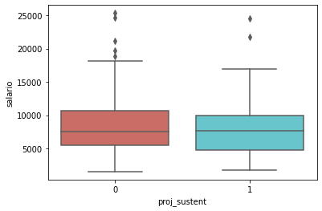

```python
sb.boxplot(x='proj_sustent', y='salario', data=salariosBase, palette='hls');
```

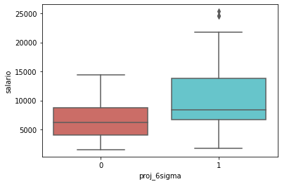

```python
sb.boxplot(x='proj_6sigma', y='salario', data=salariosBase, palette='hls');
```

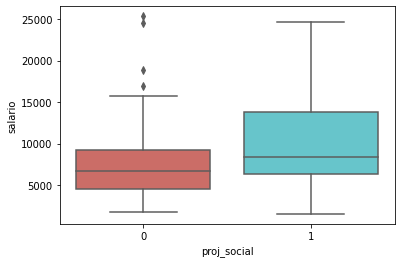

```python
sb.boxplot(x='proj_social', y='salario', data=salariosBase, palette='hls');
```

### Criação do teste qui-quadrado

Faremos isso para descobrir a associação entre as variáveis qualitativas.

Transformamos a variável sálario em qualitativa com o nome de fx_salario e testaremos com:

- salario x proj_sustent
- salario x proj_6sigma
- salario x proj_social

```python
Q1 =  np.percentile(salariosBase['salario'], 25)
Q2 =  np.percentile(salariosBase['salario'], 50)
Q3 =  np.percentile(salariosBase['salario'], 75)
maximo = max(salariosBase['salario'])
print(Q1, Q2, Q3, maximo)
```

```
5491.2300000000005 7551.125 10584.685 25329.91
```

```python
salariosBase.loc[(salariosBase.salario >= 0) & (salariosBase.salario <= Q1), 'fx_salario']=1.0
salariosBase.loc[(salariosBase.salario > Q1) & (salariosBase.salario <= Q2), 'fx_salario']=2.0
salariosBase.loc[(salariosBase.salario>  Q2)  & (salariosBase.salario <=Q3), 'fx_salario']=3.0
salariosBase.loc[(salariosBase.salario >  Q3) & (salariosBase.salario <= maximo), 'fx_salario']=4.0
```

```python
salariosBase.info()
```

```
<class 'pandas.core.frame.DataFrame'>
RangeIndex: 180 entries, 0 to 179
Data columns (total 10 columns):
 #   Column        Non-Null Count  Dtype
---  ------        --------------  -----
 0   salario       180 non-null    float64
 1   idade         180 non-null    int64
 2   tempocasa     180 non-null    int64
 3   escolar       180 non-null    int64
 4   qproj_estra   180 non-null    int64
 5   proj_sustent  180 non-null    int64
 6   proj_6sigma   180 non-null    int64
 7   proj_social   180 non-null    int64
 8   notaavalia    180 non-null    float64
 9   fx_salario    180 non-null    float64
dtypes: float64(3), int64(7)
memory usage: 14.2 KB
```

```python
salariosBase.head()
```

|  | salario | idade | tempocasa | escolar | qproj_estra | proj_sustent | proj_6sigma | proj_social | notaavalia | fx_salario |
| --- | --- | --- | --- | --- | --- | --- | --- | --- | --- | --- |
| 0 | 8000.80 | 25 | 4 | 11 | 1 | 1 | 1 | 0 | 79.38 | 3.0 |
| 1 | 8500.17 | 24 | 5 | 11 | 0 | 0 | 1 | 0 | 84.13 | 3.0 |
| 2 | 3350.59 | 22 | 1 | 12 | 0 | 0 | 0 | 0 | 46.15 | 1.0 |
| 3 | 9500.24 | 28 | 4 | 14 | 1 | 0 | 0 | 1 | 83.85 | 3.0 |
| 4 | 1500.63 | 18 | 2 | 12 | 0 | 0 | 0 | 1 | 73.64 | 1.0 |

### Realizando o crosstab

Agora vamos realizar o crosstab das variáveis:

- salario x proj_sustent
- salario x proj_6sigma
- salario x proj_social

### Crosstab fx_salario x proj_sustent

```python
pd.crosstab(salariosBase.fx_salario, salariosBase.proj_sustent, margins=True)
```

| proj_sustent fx_salario | 0 | 1 | All |
| --- | --- | --- | --- |
| 1.0 | 32 | 13 | 45 |
| 2.0 | 34 | 11 | 45 |
| 3.0 | 31 | 14 | 45 |
| 4.0 | 33 | 12 | 45 |
| All | 130 | 50 | 180 |

```python
(salariosBase.proj_sustent.value_counts() / salariosBase.shape[0]) * 100
```

```
0    72.222222
1    27.777778
Name: proj_sustent, dtype: float64
```

```python
table_proj_sustent = pd.crosstab(salariosBase.fx_salario,salariosBase.proj_sustent)
```

```python
table_proj_sustent
```

| proj_sustent fx_salario | 0 | 1 |
| --- | --- | --- |
| 1.0 | 32 | 13 |
| 2.0 | 34 | 11 |
| 3.0 | 31 | 14 |
| 4.0 | 33 | 12 |

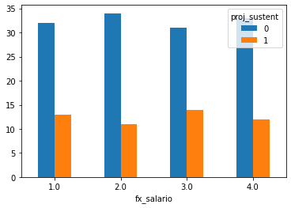

```python
barplot_proj_sustent = table_proj_sustent.plot.bar(rot=0)
```

### Crosstab fx_salario x proj_6sigma

```python
pd.crosstab(salariosBase.fx_salario, salariosBase.proj_6sigma, margins=True)
```

| proj_6sigma fx_salario | 0 | 1 | All |
| --- | --- | --- | --- |
| 1.0 | 31 | 14 | 45 |
| 2.0 | 23 | 22 | 45 |
| 3.0 | 16 | 29 | 45 |
| 4.0 | 11 | 34 | 45 |
| All | 81 | 99 | 180 |

```python
(salariosBase.proj_6sigma.value_counts() / salariosBase.shape[0]) * 100
```

```
1    55.0
0    45.0
Name: proj_6sigma, dtype: float64
```

```python
table_proj_6sigma = pd.crosstab(salariosBase.fx_salario,salariosBase.proj_6sigma)
```

```python
table_proj_6sigma
```

| proj_6sigma fx_salario | 0 | 1 |
| --- | --- | --- |
| 1.0 | 31 | 14 |
| 2.0 | 23 | 22 |
| 3.0 | 16 | 29 |
| 4.0 | 11 | 34 |

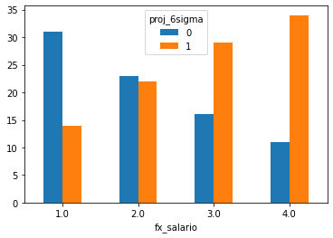

```python
barplot_proj_6sigma = table_proj_6sigma.plot.bar(rot=0)
```

### Crosstab fx_salario x proj_social

```python
pd.crosstab(salariosBase.fx_salario, salariosBase.proj_social, margins=True)
```

| proj_social fx_salario | 0 | 1 | All |
| --- | --- | --- | --- |
| 1.0 | 29 | 16 | 45 |
| 2.0 | 26 | 19 | 45 |
| 3.0 | 22 | 23 | 45 |
| 4.0 | 13 | 32 | 45 |
| All | 90 | 90 | 180 |

```python
(salariosBase.proj_social.value_counts() / salariosBase.shape[0]) * 100
```

```
0    50.0
1    50.0
Name: proj_social, dtype: float64
```

```python
table_proj_social = pd.crosstab(salariosBase.fx_salario,salariosBase.proj_social)
```

```python
table_proj_social
```

| proj_social fx_salario | 0 | 1 |
| --- | --- | --- |
| 1.0 | 29 | 16 |
| 2.0 | 26 | 19 |
| 3.0 | 22 | 23 |
| 4.0 | 13 | 32 |

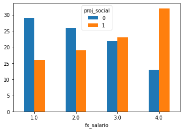

```python
barplot_proj_social = table_proj_social.plot.bar(rot=0)
```

### Utilização da função chi2_contingency

Nós utilizaremos essa função para calcular a estatística qui-quadrado e o p-value para o teste de hipótese de independência das frequências observadas na tabela de contingências:

- table_proj_sustent
- table_proj_6sigma
- table_proj_social

### Teste de hipótese

- H0: não há relação entre salario e as variaveis que serão testadas
- H1: há relação entre salario e as variaveis que serão testadas

**α = 0,05 (5%)**

### Função testChi2

Criada para evitar a repetição da instrução de teste.

```python
def testChi2(dof, expected, stat, p):
  print('Graus de liberdade: dof=%d' % dof)

  print('\n Tabela Esperada:')
  print(expected)

  # interpret test-statistic
  prob = 0.95
  critical = chi2.ppf(prob, dof)

  print('\n probability=%.3f, critical=%.3f, stat=%.3f' % (prob, critical, stat))

  if abs(stat) >= critical:
    print('\n Dependente (rejeita H0)')
  else:
    print('\n Independente (falha em rejeitar H0)')
  # interpret p-value
  alpha = 1.0 - prob
  print('\n significance=%.3f, p=%.3f' % (alpha, p))
  if p <= alpha:
    print('\n Dependente (rejeita H0)')
  else:
    print('\n Independente (falha em rejeitar H0)')
```

### chi2_contingency para table_proj_sustent

```python
stat_proj_sustent, p_proj_sustent, dof_proj_sustent, expected_proj_sustent = chi2_contingency(table_proj_sustent)
p_proj_sustent
```

```
0.9069120268597668
```

```python
testChi2(dof=dof_proj_sustent, expected=expected_proj_sustent, stat=stat_proj_sustent, p=p_proj_sustent)
```

```
Graus de liberdade: dof=3

 Tabela Esperada:
[[32.5 12.5]
 [32.5 12.5]
 [32.5 12.5]
 [32.5 12.5]]

 probability=0.950, critical=7.815, stat=0.554

 Independente (falha em rejeitar H0)

 significance=0.050, p=0.907

 Independente (falha em rejeitar H0)
```

### chi2_contingency para table_proj_6sigma

```python
stat_proj_6sigma, p_proj_6sigma, dof_proj_6sigma, expected_proj_6sigma = chi2_contingency(table_proj_6sigma)
p_proj_6sigma
```

```
0.0001429985968152404
```

```python
testChi2(dof=dof_proj_6sigma, expected=expected_proj_6sigma, stat=stat_proj_6sigma, p=p_proj_6sigma)
```

```
Graus de liberdade: dof=3

 Tabela Esperada:
[[20.25 24.75]
 [20.25 24.75]
 [20.25 24.75]
 [20.25 24.75]]

 probability=0.950, critical=7.815, stat=20.359

 Dependente (rejeita H0)

 significance=0.050, p=0.000

 Dependente (rejeita H0)
```

### chi2_contingency para table_proj_social

```python
stat_proj_social, p_proj_social, dof_proj_social, expected_proj_social = chi2_contingency(table_proj_social)
p_proj_social
```

```
0.004883155862460387
```

```python
testChi2(dof_proj_social, expected_proj_social, stat_proj_social, p_proj_social)
```

```
Graus de liberdade: dof=3

 Tabela Esperada:
[[22.5 22.5]
 [22.5 22.5]
 [22.5 22.5]
 [22.5 22.5]]

 probability=0.950, critical=7.815, stat=12.889

 Dependente (rejeita H0)

 significance=0.050, p=0.005

 Dependente (rejeita H0)
```

### Execução do teste utilizando researchpy

Aqui nós vamos executar a função crosstab utilizando o teste chi-square que irá realizar o teste qui-quadrado das nossas variáveis:

- fx_salario x proj_sustent
- fx_salario x proj_6sigma
- fx_salario x proj_social

```python
resultado_fx_salario_proj_sustent = researchpy.crosstab(salariosBase['fx_salario'], salariosBase['proj_sustent'], test='chi-square')
```

```python
resultado_fx_salario_proj_sustent
```

```
(             proj_sustent
 proj_sustent            0   1  All
 fx_salario
 1.0                    32  13   45
 2.0                    34  11   45
 3.0                    31  14   45
 4.0                    33  12   45
 All                   130  50  180,                 Chi-square test  results
 0  Pearson Chi-square ( 3.0) =    0.5538
 1                    p-value =    0.9069
 2                 Cramer's V =    0.0555)
```

```python
resultado_fx_salario_proj_6sigma = researchpy.crosstab(salariosBase['fx_salario'], salariosBase['proj_6sigma'], test='chi-square')
```

```python
resultado_fx_salario_proj_6sigma
```

```
(            proj_6sigma
 proj_6sigma           0   1  All
 fx_salario
 1.0                  31  14   45
 2.0                  23  22   45
 3.0                  16  29   45
 4.0                  11  34   45
 All                  81  99  180,                 Chi-square test  results
 0  Pearson Chi-square ( 3.0) =   20.3591
 1                    p-value =    0.0001
 2                 Cramer's V =    0.3363)
```

```python
resultado_fx_salario_proj_social = researchpy.crosstab(salariosBase['fx_salario'], salariosBase['proj_social'], test='chi-square')
```

```python
resultado_fx_salario_proj_social
```

```
(            proj_social
 proj_social           0   1  All
 fx_salario
 1.0                  29  16   45
 2.0                  26  19   45
 3.0                  22  23   45
 4.0                  13  32   45
 All                  90  90  180,                 Chi-square test  results
 0  Pearson Chi-square ( 3.0) =   12.8889
 1                    p-value =    0.0049
 2                 Cramer's V =    0.2676)
```

### Inicio do nosso teste utilizando o algoritmo de regressão linear

Agora que já realizamos a análise exploratória, verificamos todos os dados podemos então rodar a nossa regressão linear que irá verificar o relacionamento das nossas variáveis.

### Atribuição da função para o modelo utilizando regressão linear

Também verificamos o coeficiente para rodar o nosso modelo

```python
lm = LinearRegression()
```

```python
x = salariosBase[['idade', 'tempocasa', 'escolar', 'qproj_estra', 'proj_sustent', 'proj_6sigma', 'proj_social', 'notaavalia']]

y = salariosBase[['salario']]
```

```python
x
```

|  | idade | tempocasa | escolar | qproj_estra | proj_sustent | proj_6sigma | proj_social | notaavalia |
| --- | --- | --- | --- | --- | --- | --- | --- | --- |
| 0 | 25 | 4 | 11 | 1 | 1 | 1 | 0 | 79.38 |
| 1 | 24 | 5 | 11 | 0 | 0 | 1 | 0 | 84.13 |
| 2 | 22 | 1 | 12 | 0 | 0 | 0 | 0 | 46.15 |
| 3 | 28 | 4 | 14 | 1 | 0 | 0 | 1 | 83.85 |
| 4 | 18 | 2 | 12 | 0 | 0 | 0 | 1 | 73.64 |
| ... | ... | ... | ... | ... | ... | ... | ... | ... |
| 175 | 36 | 14 | 13 | 0 | 1 | 1 | 1 | 88.87 |
| 176 | 26 | 15 | 14 | 1 | 0 | 1 | 1 | 85.45 |
| 177 | 36 | 3 | 14 | 1 | 0 | 0 | 1 | 76.72 |
| 178 | 28 | 11 | 12 | 0 | 1 | 0 | 1 | 76.22 |
| 179 | 21 | 3 | 15 | 1 | 1 | 0 | 1 | 79.40 |

180 rows × 8 columns

```python
y
```

|  | salario |
| --- | --- |
| 0 | 8000.80 |
| 1 | 8500.17 |
| 2 | 3350.59 |
| 3 | 9500.24 |
| 4 | 1500.63 |
| ... | ... |
| 175 | 7896.70 |
| 176 | 10575.13 |
| 177 | 6309.66 |
| 178 | 2100.68 |
| 179 | 4059.13 |

180 rows × 1 columns

### Iniciando o processo de treino do nosso modelo

```python
lm.fit(x,y)
```

```
LinearRegression()
```

```python
# Termo independente no modelo linear
lm.intercept_
```

```
array([-9011.78914327])
```

```python
# Coeficientes estaimados para o nosso problema de regressão linear
lm.coef_
```

```
array([[ 179.31785454,  207.14917154,  571.52233188,  596.95436422,
         503.25814193, 1729.11169862, 1193.86954237,    6.43057797]])
```

### Visualizando os coeficientes

A seguir nos verificaremos os coeficientes das variáveis testadas para o nosso modelo.

```python
coeficientes = pd.concat([pd.DataFrame(x.columns),pd.DataFrame(np.transpose(lm.coef_))], axis = 1)
```

```python
coeficientes.T
```

|  | 0 | 1 | 2 | 3 | 4 | 5 | 6 | 7 |
| --- | --- | --- | --- | --- | --- | --- | --- | --- |
| 0 | idade | tempocasa | escolar | qproj_estra | proj_sustent | proj_6sigma | proj_social | notaavalia |
| 0 | 179.317855 | 207.149172 | 571.522332 | 596.954364 | 503.258142 | 1729.111699 | 1193.869542 | 6.430578 |

```python
X = salariosBase[salariosBase.columns[1:9]]

y = salariosBase[['salario']]
```

```python
total_amostras = 101
tamanho_do_teste = 0.05
```

### Criando nossa base de testes e treino

Utilizaremos a função train_test_split que irá separar nosso dataset em teste e treino.

```python
X_train, X_test, y_train, y_test = train_test_split(X,y, test_size = tamanho_do_teste, random_state = total_amostras)
```

### Visualização do resultado com Mínimos Quadrados Ordinários

Nós utilizamos a técnica de Mínimos Quadrados Ordinários que consiste em uma técnica de otimização matemática que procura encontrar o melhor ajuste para um conjunto de dados tentando minimizar a soma dos quadrados das diferenças entre o valor estimado e os dados observados.

```python
X_ = sm.add_constant(X_train)

model = sm.OLS(y_train, X_).fit()

print(model.summary())
```

```
                            OLS Regression Results
==============================================================================
Dep. Variable:                salario   R-squared:                       0.618
Model:                            OLS   Adj. R-squared:                  0.600
Method:                 Least Squares   F-statistic:                     32.83
Date:                Fri, 16 Sep 2022   Prob (F-statistic):           2.92e-30
Time:                        21:53:01   Log-Likelihood:                -1605.0
No. Observations:                 171   AIC:                             3228.
Df Residuals:                     162   BIC:                             3256.
Df Model:                           8
Covariance Type:            nonrobust
================================================================================
                   coef    std err          t      P>|t|      [0.025      0.975]
--------------------------------------------------------------------------------
const        -9223.5683   1713.319     -5.383      0.000   -1.26e+04   -5840.250
idade          179.8166     29.312      6.134      0.000     121.933     237.700
tempocasa      196.9574     41.860      4.705      0.000     114.296     279.618
escolar        601.9550     98.534      6.109      0.000     407.378     796.532
qproj_estra    597.7543    236.873      2.524      0.013     129.998    1065.510
proj_sustent   597.9183    529.065      1.130      0.260    -446.836    1642.672
proj_6sigma   1779.4345    473.560      3.758      0.000     844.287    2714.582
proj_social   1024.1501    497.210      2.060      0.041      42.302    2005.998
notaavalia       6.5617     14.471      0.453      0.651     -22.014      35.138
==============================================================================
Omnibus:                        3.153   Durbin-Watson:                   2.031
Prob(Omnibus):                  0.207   Jarque-Bera (JB):                2.696
Skew:                           0.277   Prob(JB):                        0.260
Kurtosis:                       3.269   Cond. No.                         615.
==============================================================================

Notes:
[1] Standard Errors assume that the covariance matrix of the errors is correctly specified.
```

### R2 da regressão

No caso anterior no **R2=0.600**, neste caso ficou em **60%** após avaliarmos isso decidimos então alterar as variáveis significantes e rodar o modelo novamente.

```python
X_train, X_test, y_train, y_test = train_test_split(salariosBase.drop(['salario','notaavalia'],axis=1), salariosBase['salario'],test_size=tamanho_do_teste, random_state=17)
```

```python
X_ = sm.add_constant(X_train)

modelo = sm.OLS(y_train, X_).fit()

print(modelo.summary())
```

```
                            OLS Regression Results
==============================================================================
Dep. Variable:                salario   R-squared:                       0.840
Model:                            OLS   Adj. R-squared:                  0.832
Method:                 Least Squares   F-statistic:                     106.0
Date:                Fri, 16 Sep 2022   Prob (F-statistic):           2.43e-60
Time:                        21:53:01   Log-Likelihood:                -1532.2
No. Observations:                 171   AIC:                             3082.
Df Residuals:                     162   BIC:                             3111.
Df Model:                           8
Covariance Type:            nonrobust
================================================================================
                   coef    std err          t      P>|t|      [0.025      0.975]
--------------------------------------------------------------------------------
const        -5356.1192    909.582     -5.889      0.000   -7152.284   -3559.954
idade           82.0865     20.009      4.102      0.000      42.574     121.599
tempocasa       87.1435     28.955      3.010      0.003      29.965     144.322
escolar        207.3210     68.544      3.025      0.003      71.966     342.677
qproj_estra    414.3179    153.770      2.694      0.008     110.666     717.970
proj_sustent   158.9158    346.483      0.459      0.647    -525.290     843.122
proj_6sigma    537.5852    322.239      1.668      0.097     -98.746    1173.916
proj_social    137.6092    331.049      0.416      0.678    -516.119     791.337
fx_salario    2780.5329    182.768     15.213      0.000    2419.618    3141.448
==============================================================================
Omnibus:                       57.351   Durbin-Watson:                   2.235
Prob(Omnibus):                  0.000   Jarque-Bera (JB):              213.852
Skew:                           1.248   Prob(JB):                     3.65e-47
Kurtosis:                       7.877   Cond. No.                         223.
==============================================================================

Notes:
[1] Standard Errors assume that the covariance matrix of the errors is correctly specified.
```

### Ajuste do modelo

Agora que ajustamos o nosso treino e teste nosso **R2=0.832**, neste caso ficando então em **83%**

### Medidas de erro

Agora para testar nós utilizamos duas medidas de erro e são elas:

- mean_absolute_error
- mean_squared_error

Onde mean_absolute_error que é o erro absoluto médio é uma medida de erros entre observações pareadas que expressam o mesmo fenômeno.

E mean_squared_error irá retornar o nosso erro quadrático médio ou risco quadrático de um estimador.

Vamos então agora cálcular o valor predito da nossa variável de reposta que é retornada da nossa amostrar de treino.

```python
y_train_pred = modelo.predict(X_)
```

```python
y_train_pred
```

```
0       8777.565257
90     10470.862083
11      5795.415518
172    14978.489561
73     15630.522214
           ...
57      3390.786433
150     3667.588207
134     6072.017259
143    12812.114773
111    13167.159182
Length: 171, dtype: float64
```

### Ajustando as medidas de erro da amostra

```python
me1    = round((y_train-y_train_pred).mean(),2)
mae1   = (mean_absolute_error(y_train, y_train_pred)).round(2)
mse1   = (mean_squared_error(y_train, y_train_pred)).round(2)
rmse1  = (np.sqrt(mean_squared_error(y_train, y_train_pred))).round(2)
mpe1   = round(((y_train - y_train_pred)/y_train).mean(),2)
mape1  =  round((mae1/y_train).mean(),2)
```

```python
lista_com_as_medidas = [me1, mae1,mse1,rmse1,mpe1, mape1]

pd.DataFrame({"treino_resultado": lista_com_as_medidas})
```

|  | treino_resultado |
| --- | --- |
| 0 | -0.00 |
| 1 | 1321.36 |
| 2 | 3551146.93 |
| 3 | 1884.45 |
| 4 | -0.02 |
| 5 | 0.21 |

### Gráficos de Diagnóstico dos Resíduos

Agora nós faremos a parte visual e veriricar nosso Residuals vs Fitted essa informações indicam a existência de padrões não lineares nos resíduos.

Explicações a cerca dos itens:

- Normal Q-Q - examina se os resíduos são normalmente distribuídos. É bom que os pontos residuais sigam a linha reta.
- Homoscedasticidade - verifica a homogeneidade de variância dos resíduos. A linha horizontal com pontos igualmente dispersos é uma boa indicação de homoscedasticidade.
- Residuals vs Leverage - identifica casos influentes, ou seja, valores extremos que podem influenciar os resultados da regressão quando incluídos ou excluídos da análise.
- Antes de se construir os gráficos, em primeiro construir-se-á o modelo de resíduo para cada diagnóstico.

Criaremos então a seguir os diagnósticos para então plotar os gráficos

```python
modelo_ajust_y = modelo.fittedvalues
modelo_residuos = modelo.resid
modelo_norm_resid = modelo.get_influence().resid_studentized_internal
modelo_norm_resid_abs = np.sqrt(np.abs(modelo_norm_resid))
modelo_outliers = modelo.get_influence().hat_matrix_diag
distancia_cook = modelo.get_influence().cooks_distance[0]
```

```python
modelo_ajust_y.head()
```

```
0       8777.565257
90     10470.862083
11      5795.415518
172    14978.489561
73     15630.522214
dtype: float64
```

```python
modelo_norm_resid
```

```
array([-0.41372582, -1.30365394, -0.15474994, -0.62682323, -1.47671575,
       -0.83119167, -0.26841235, -0.77246125, -0.72631581,  0.61306468,
        0.81793179,  0.96393368, -0.84368306,  0.03930418, -0.38828879,
        3.18165483, -1.19203684,  0.08064021, -0.12666786,  2.14024497,
        0.62641817,  0.07609753, -0.26694983, -2.86629919,  0.49712426,
       -0.46159803,  0.20869222, -0.06176111,  0.06487283, -1.16506695,
        0.34520695,  0.04563745,  1.97291097, -0.10749237, -0.05311782,
        0.1161306 , -1.48658701,  4.64269477, -0.92989752, -1.04677052,
       -1.04505439, -0.95508077,  0.18510345, -1.03357434, -0.25800735,
        0.13761973,  1.2067251 ,  0.93459222,  0.0471428 , -0.17451346,
        1.18894671,  0.44140174, -0.19310928,  0.0761631 ,  1.92980264,
       -0.48216906, -0.90133404, -0.49653719,  1.14421218,  0.76524478,
       -0.33308621, -0.1771622 , -0.29851955, -0.75126926, -0.31046609,
       -1.72054975, -0.06727465, -0.34119934, -0.33141177,  0.68311375,
       -0.29235461,  0.32359383, -1.10130273, -1.59315345,  1.90170545,
       -1.877028  , -0.46117855, -0.07281963,  0.56711951,  0.28659393,
       -1.20983641, -1.15605013, -0.48581843, -0.43202389,  0.26097411,
        0.06633036, -0.10627302, -0.9053784 ,  0.15368431, -0.13994558,
       -0.19201608, -1.22488047,  0.2937315 , -0.53459883,  0.38594224,
        1.00563196, -0.11083857, -0.08906039, -1.07051332,  0.19410988,
        0.52834439, -0.86636717,  4.80645179,  0.86782007,  0.01846646,
       -0.34978914,  0.03258479,  0.74674696, -1.03944157,  0.84507186,
        0.21736435,  1.1518153 ,  0.38886835,  0.81825526, -2.37898626,
       -0.29012878, -0.8286432 , -0.44953097, -0.02063869,  0.00784865,
        0.7742894 , -0.7256796 , -0.44171673, -0.0721979 , -1.42223021,
        1.20357925,  0.55519737, -0.70776021,  0.95069613, -0.19721321,
        0.30983525,  1.41170937, -0.37187608, -1.1074557 ,  0.08212781,
        0.96991138, -0.3572697 ,  0.44228926, -0.30180625, -0.53071782,
       -0.13383115,  0.99557166,  0.41696725, -0.85120609,  2.40170194,
        0.16279586,  0.81202214, -1.00232426,  0.24545725,  0.75132641,
       -0.14779661, -0.45514604, -0.33356724,  0.22393817,  0.05416107,
        0.46468069,  0.43876644, -0.02511206, -0.26727797,  0.17306349,
        0.4648694 ,  1.33714202, -0.93309237,  1.76903896, -0.70658941,
       -1.7081736 ,  0.58973881,  0.02103974,  0.74518748, -0.61085494,
        0.50953213])
```

### Criação de um dataframe para visualização dos dados de sálario

Criamos um dataframe para então verificar a variável de sálario x as observadas pelo nosso modelo

```python
data_salario_x_modelo = pd.concat([y_train, modelo_ajust_y], axis=1)
```

```python
data_salario_x_modelo.head()
```

|  | salario | 0 |
| --- | --- | --- |
| 0 | 8000.80 | 8777.565257 |
| 90 | 8025.24 | 10470.862083 |
| 11 | 5500.80 | 5795.415518 |
| 172 | 13827.91 | 14978.489561 |
| 73 | 12843.63 | 15630.522214 |

### Plot do gráfico observado x estimado

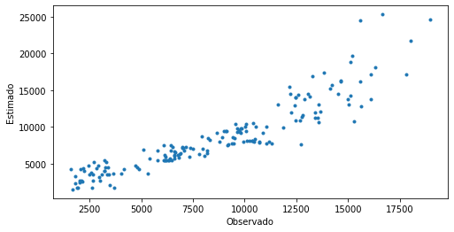

```python
plt.figure(figsize=(8, 4))
plt.scatter(y_train_pred ,y_train, marker='.')
plt.xlabel("Observado")
plt.ylabel("Estimado")
```

### Verificação de padrão nos resíduos

Aqui executamos um plot para verificar se existe algum problema em nosso modelo linear, este médo é usado para podermos rep representar graficamente os resíduos da regressão linear e com isso definirmos visualmente a suposição da nossa normalidade, porém ainda não mostra se podemos aceitar os resíduos como normais.

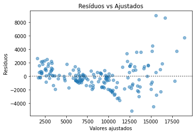

```python
plot_lm_1 = plt.figure()
plot_lm_1.axes[0] = sb.residplot(modelo_ajust_y, data_salario_x_modelo.columns[-0], data=data_salario_x_modelo, scatter_kws={'alpha': 0.5}, line_kws={'color': 'red', 'lw': 1, 'alpha': 0.8})

plot_lm_1.axes[0].set_title('Resíduos vs Ajustados')
plot_lm_1.axes[0].set_xlabel('Valores ajustados')
plot_lm_1.axes[0].set_ylabel('Resíduos')
```

### Teste de normalidade

Plot de gráfico para verificar se nossos resíduos estão normalmente distribuidos

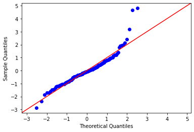

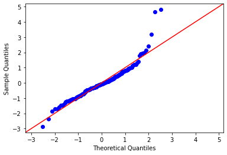

```python
sm.qqplot(modelo_norm_resid, line='45')
```

### Shapiro-Wilk

```python
shapiro_test = stats.shapiro(modelo_norm_resid)
shapiro_test
```

```
ShapiroResult(statistic=0.9174700379371643, pvalue=2.9718696836766867e-08)
```

### Teste de Homoscedasticidade

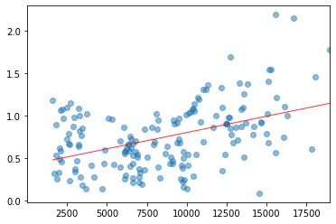

```python
plot_lm_3 = plt.figure()
plt.scatter(modelo_ajust_y, modelo_norm_resid_abs, alpha=0.5);
sb.regplot(modelo_ajust_y, modelo_norm_resid_abs,
            scatter=False,
            ci=False,
            line_kws={'color': 'red', 'lw': 1, 'alpha': 0.8});
plot_lm_3.axes[0].set_xlim(4, max(modelo_ajust_y)+0.05)

plt.show()
```

### Pontos influentes e valores extremos

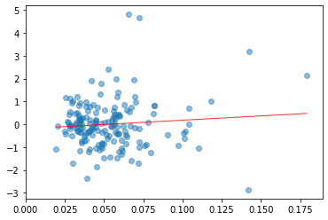

```python
plot_lm_4 = plt.figure();
plt.scatter(modelo_outliers, modelo_norm_resid, alpha=0.5);
sb.regplot(modelo_outliers, modelo_norm_resid,
            scatter=False,
            ci=False,
            line_kws={'color': 'red', 'lw': 1, 'alpha': 0.8});
plot_lm_4.axes[0].set_xlim(0, max(modelo_outliers)+0.01)

plt.show()
```

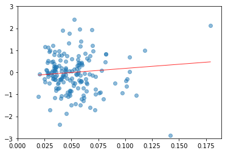

```python
plot_lm_4 = plt.figure();
plt.scatter(modelo_outliers, modelo_norm_resid, alpha=0.5);
sb.regplot(modelo_outliers, modelo_norm_resid,
            scatter=False,
            ci=False,
            line_kws={'color': 'red', 'lw': 1, 'alpha': 0.8});
plot_lm_4.axes[0].set_xlim(0, max(modelo_outliers)+0.01);
plot_lm_4.axes[0].set_ylim(-3, 3)

plt.show()
```

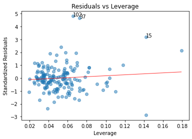

```python
plot_lm_4 = plt.figure();
plt.scatter(modelo_outliers, modelo_norm_resid, alpha=0.5);
sb.regplot(modelo_outliers, modelo_norm_resid,
            scatter=False,
            ci=False,
            line_kws={'color': 'red', 'lw': 1, 'alpha': 0.8});
plot_lm_4.axes[0].set_title('Residuals vs Leverage')
plot_lm_4.axes[0].set_xlabel('Leverage')
plot_lm_4.axes[0].set_ylabel('Standardized Residuals');

# annotations
leverage_top_3 = np.flip(np.argsort(distancia_cook), 0)[:3]
for i in leverage_top_3:
    plot_lm_4.axes[0].annotate(i,
                                 xy=(modelo_outliers[i],
                                     modelo_norm_resid[i]))
```

### MODELO COM ÁRVORE DE DECISÃO

Rodaremos agora a nossa base utilizando o modelo de árvore de decisão e com isso decidiremos qual é o melhor modelo a ser utilizado.

```python
Classif_tree = DecisionTreeClassifier(criterion='entropy')
```

```python
salarios = pd.read_csv(r'Arquivo_Salarios_Colaboradores_2021.csv', sep=';')
```

### Testes da nossa árvore de decisão

Para iniciar nós iremos verificar as variáveis

- qproj_estra
- proj_sustent
- proj_6sigma
- proj_social

```python
salarios.head()
```

|  | Ordem | salario | idade | tempocasa | escolar | qproj_estra | proj_sustent | proj_6sigma | proj_social | notaavalia |
| --- | --- | --- | --- | --- | --- | --- | --- | --- | --- | --- |
| 0 | 1 | 8000.80 | 25 | 4 | 11 | 1 | 1 | 1 | 0 | 79.38 |
| 1 | 2 | 8500.17 | 24 | 5 | 11 | 0 | 0 | 1 | 0 | 84.13 |
| 2 | 3 | 3350.59 | 22 | 1 | 12 | 0 | 0 | 0 | 0 | 46.15 |
| 3 | 4 | 9500.24 | 28 | 4 | 14 | 1 | 0 | 0 | 1 | 83.85 |
| 4 | 5 | 1500.63 | 18 | 2 | 12 | 0 | 0 | 0 | 1 | 73.64 |

```python
X_train, X_test, y_train, y_test = train_test_split(salarios.drop(['qproj_estra', 'Ordem'],axis=1),salarios['qproj_estra'],test_size=0.3, random_state=17)
```

```python
classif = Classif_tree.fit(X_train, y_train)
```

```python
classif.feature_importances_
```

```
array([0.3438573 , 0.13470208, 0.14362226, 0.11079426, 0.03268949,
       0.03178173, 0.06855475, 0.13399813])
```

```python
for feature,importancia in zip(X_train.columns,classif.feature_importances_):
    print("{}:{}".format(feature, (importancia * 100).round()))
```

```
salario:34.0
idade:13.0
tempocasa:14.0
escolar:11.0
proj_sustent:3.0
proj_6sigma:3.0
proj_social:7.0
notaavalia:13.0
```

```python
y_pred_all = classif.predict(X_test)
```

```python
from sklearn.metrics import confusion_matrix

confusion_matrix = confusion_matrix(y_test, y_pred_all)
confusion_matrix
```

```
array([[ 6,  4,  0,  0,  0,  0,  0,  0],
       [ 3, 20,  3,  1,  0,  0,  0,  0],
       [ 1,  1,  1,  2,  0,  0,  0,  0],
       [ 0,  2,  0,  2,  0,  0,  0,  0],
       [ 1,  3,  0,  0,  0,  0,  0,  0],
       [ 0,  1,  0,  0,  0,  0,  0,  0],
       [ 0,  0,  1,  0,  0,  0,  0,  0],
       [ 0,  0,  2,  0,  0,  0,  0,  0]])
```

```python
print(classification_report(y_test, y_pred_all, zero_division=True))
```

```
              precision    recall  f1-score   support

           0       0.55      0.60      0.57        10
           1       0.65      0.74      0.69        27
           2       0.14      0.20      0.17         5
           3       0.40      0.50      0.44         4
           4       1.00      0.00      0.00         4
           5       1.00      0.00      0.00         1
           6       1.00      0.00      0.00         1
           7       1.00      0.00      0.00         2

    accuracy                           0.54        54
   macro avg       0.72      0.26      0.23        54
weighted avg       0.61      0.54      0.50        54
```

### Teste com proj_sustent

```python
X_train, X_test, y_train, y_test = train_test_split(salarios.drop(['proj_sustent', 'Ordem'],axis=1),salarios['proj_sustent'],test_size=0.3, random_state=17)
```

```python
classif = Classif_tree.fit(X_train, y_train)
```

```python
classif.feature_importances_
```

```
array([0.21229964, 0.15667069, 0.11319798, 0.09998194, 0.2483712 ,
       0.03980373, 0.06312765, 0.06654718])
```

```python
for feature,importancia in zip(X_train.columns,classif.feature_importances_):
    print("{}:{}".format(feature, (importancia * 100).round()))
```

```
salario:21.0
idade:16.0
tempocasa:11.0
escolar:10.0
qproj_estra:25.0
proj_6sigma:4.0
proj_social:6.0
notaavalia:7.0
```

```python
y_pred_all = classif.predict(X_test)
```

```python
from sklearn.metrics import confusion_matrix

confusion_matrix = confusion_matrix(y_test, y_pred_all)
confusion_matrix
```

```
array([[25, 11],
       [10,  8]])
```

```python
print(classification_report(y_test, y_pred_all, zero_division=True))
```

```
              precision    recall  f1-score   support

           0       0.71      0.69      0.70        36
           1       0.42      0.44      0.43        18

    accuracy                           0.61        54
   macro avg       0.57      0.57      0.57        54
weighted avg       0.62      0.61      0.61        54
```

### Teste com proj_6sigma

```python
X_train, X_test, y_train, y_test = train_test_split(salarios.drop(['proj_6sigma', 'Ordem'],axis=1),salarios['proj_6sigma'],test_size=0.3, random_state=17)
```

```python
classif = Classif_tree.fit(X_train, y_train)
```

```python
classif.feature_importances_
```

```
array([0.27815211, 0.12965474, 0.18307017, 0.1137612 , 0.03176913,
       0.06072852, 0.        , 0.20286414])
```

```python
for feature,importancia in zip(X_train.columns,classif.feature_importances_):
    print("{}:{}".format(feature, (importancia * 100).round()))
```

```
salario:28.0
idade:13.0
tempocasa:18.0
escolar:11.0
qproj_estra:3.0
proj_sustent:6.0
proj_social:0.0
notaavalia:20.0
```

```python
y_pred_all = classif.predict(X_test)
```

```python
from sklearn.metrics import confusion_matrix

confusion_matrix = confusion_matrix(y_test, y_pred_all)
confusion_matrix
```

```
array([[12,  8],
       [ 9, 25]])
```

```python
print(classification_report(y_test, y_pred_all, zero_division=True))
```

```
              precision    recall  f1-score   support

           0       0.57      0.60      0.59        20
           1       0.76      0.74      0.75        34

    accuracy                           0.69        54
   macro avg       0.66      0.67      0.67        54
weighted avg       0.69      0.69      0.69        54
```

### Teste com proj_social

```python
X_train, X_test, y_train, y_test = train_test_split(salarios.drop(['proj_social', 'Ordem'],axis=1),salarios['proj_social'],test_size=0.3, random_state=17)
```

```python
classif = Classif_tree.fit(X_train, y_train)
```

```python
classif.feature_importances_
```

```
array([0.22447858, 0.03189109, 0.16481609, 0.18086928, 0.08681725,
       0.12652239, 0.08757298, 0.09703234])
```

```python
for feature,importancia in zip(X_train.columns,classif.feature_importances_):
    print("{}:{}".format(feature, (importancia * 100).round()))
```

```
salario:22.0
idade:3.0
tempocasa:16.0
escolar:18.0
qproj_estra:9.0
proj_sustent:13.0
proj_6sigma:9.0
notaavalia:10.0
```

```python
y_pred_all = classif.predict(X_test)
```

```python
from sklearn.metrics import confusion_matrix

confusion_matrix = confusion_matrix(y_test, y_pred_all)
confusion_matrix
```

```
array([[18,  4],
       [ 7, 25]])
```

```python
print(classification_report(y_test, y_pred_all, zero_division=True))
```

```
              precision    recall  f1-score   support

           0       0.72      0.82      0.77        22
           1       0.86      0.78      0.82        32

    accuracy                           0.80        54
   macro avg       0.79      0.80      0.79        54
weighted avg       0.80      0.80      0.80        54
```

### Variaveis para a árvore

```python
salarios_dataset = salarios[['proj_social', 'salario', 'idade', 'tempocasa', 'escolar', 'qproj_estra', 'proj_sustent', 'proj_6sigma', 'notaavalia']]
```

### Divisão treino-teste

Agora executaremos nosso algoritmo novamente pois conseguimos encontrar a escala que gostariamos.

```python
x = salarios_dataset.values[:, 1:]
y = salarios_dataset.values[:, 0]

x_train, x_test, y_train, y_test = train_test_split(x, y, test_size = 0.20, random_state = 0)
```

### Feature Scaling

```python
from sklearn.preprocessing import StandardScaler

scaler = StandardScaler()
scaler.fit(x_train)

x_train = scaler.transform(x_train)
x_test = scaler.transform(x_test)
```

### Treinamento do modelo

```python
def train_model(height):
  model = DecisionTreeClassifier(criterion = 'entropy', max_depth = height, random_state = 0)
  model.fit(x_train, y_train)
  return model
```

### Avaliação do modelo

```python
for height in range(1, 21): # 1-20
  model = train_model(height)
  y_pred = model.predict(x_test)

  print('--------------------------------------------------------------\n')
  print(f'Altura - {height}\n')
  print("Precisão: " + str(accuracy_score(y_test, y_pred)))
```

```
--------------------------------------------------------------

Altura - 1

Precisão: 0.75
--------------------------------------------------------------

Altura - 2

Precisão: 0.8055555555555556
--------------------------------------------------------------

Altura - 3

Precisão: 0.6944444444444444
--------------------------------------------------------------

Altura - 4

Precisão: 0.7222222222222222
--------------------------------------------------------------

Altura - 5

Precisão: 0.6944444444444444
--------------------------------------------------------------

Altura - 6

Precisão: 0.75
--------------------------------------------------------------

Altura - 7

Precisão: 0.7222222222222222
--------------------------------------------------------------

Altura - 8

Precisão: 0.75
```

[output cut: 45 more lines]

```
--------------------------------------------------------------

Altura - 18

Precisão: 0.75
--------------------------------------------------------------

Altura - 19

Precisão: 0.75
--------------------------------------------------------------

Altura - 20

Precisão: 0.75
```

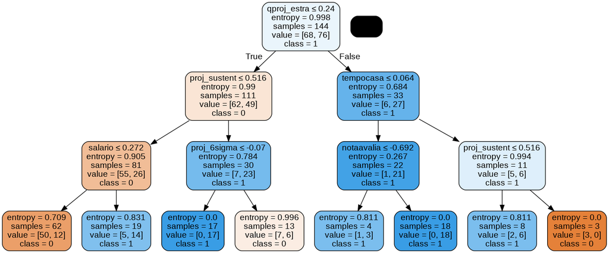

```python
from IPython.display import Image
from sklearn.tree import export_graphviz

model = train_model(3)

feature_names = ['salario', 'idade', 'tempocasa', 'escolar', 'qproj_estra', 'proj_sustent', 'proj_6sigma', 'notaavalia']

classes_names = ['%.f' % i for i in model.classes_]

dot_data = export_graphviz(model, filled=True, feature_names=feature_names, class_names=classes_names, rounded=True, special_characters=True)
graph = pydotplus.graph_from_dot_data(dot_data)

Image(graph.create_png())
graph.write_png("tree.png")
Image('tree.png')
```

### Resultado final da árvore

```python
X_train, X_test, y_train, y_test = train_test_split(salarios.drop(['proj_social', 'Ordem'],axis=1),salarios['proj_social'],test_size=0.3, random_state=17)

X_train.shape, X_test.shape
```

```
((126, 8), (54, 8))
```

```python
classif = Classif_tree.fit(X_train, y_train)
```

```python
classif.feature_importances_
```

```
array([0.22655583, 0.05275821, 0.21878805, 0.1298255 , 0.08681725,
       0.12652239, 0.08757298, 0.0711598 ])
```

```python
for feature,importancia in zip(X_train.columns,classif.feature_importances_):
    print("{}:{}".format(feature, importancia))
```

```
salario:0.22655582736793717
idade:0.052758205004239674
tempocasa:0.21878804853045838
escolar:0.12982550239043558
qproj_estra:0.08681724612937822
proj_sustent:0.12652239196619702
proj_6sigma:0.0875729764712559
notaavalia:0.07115980214009798
```

```python
y_pred_all = classif.predict(X_test)
```

```python
from sklearn.metrics import confusion_matrix
# Matriz de Confusão

confusion_matrix = confusion_matrix(y_test, y_pred_all)
confusion_matrix
```

```
array([[15,  7],
       [ 7, 25]])
```

```python
print(classification_report(y_test, y_pred_all))
```

```
              precision    recall  f1-score   support

           0       0.68      0.68      0.68        22
           1       0.78      0.78      0.78        32

    accuracy                           0.74        54
   macro avg       0.73      0.73      0.73        54
weighted avg       0.74      0.74      0.74        54
```

```python
salarios.drop(['proj_social', 'Ordem'],axis=1)
```

|  | salario | idade | tempocasa | escolar | qproj_estra | proj_sustent | proj_6sigma | notaavalia |
| --- | --- | --- | --- | --- | --- | --- | --- | --- |
| 0 | 8000.80 | 25 | 4 | 11 | 1 | 1 | 1 | 79.38 |
| 1 | 8500.17 | 24 | 5 | 11 | 0 | 0 | 1 | 84.13 |
| 2 | 3350.59 | 22 | 1 | 12 | 0 | 0 | 0 | 46.15 |
| 3 | 9500.24 | 28 | 4 | 14 | 1 | 0 | 0 | 83.85 |
| 4 | 1500.63 | 18 | 2 | 12 | 0 | 0 | 0 | 73.64 |
| ... | ... | ... | ... | ... | ... | ... | ... | ... |
| 175 | 7896.70 | 36 | 14 | 13 | 0 | 1 | 1 | 88.87 |
| 176 | 10575.13 | 26 | 15 | 14 | 1 | 0 | 1 | 85.45 |
| 177 | 6309.66 | 36 | 3 | 14 | 1 | 0 | 0 | 76.72 |
| 178 | 2100.68 | 28 | 11 | 12 | 0 | 1 | 0 | 76.22 |
| 179 | 4059.13 | 21 | 3 | 15 | 1 | 1 | 0 | 79.40 |

180 rows × 8 columns

[figure not shown]

```python
fig = plt.figure(figsize=(16,12))
a = plot_tree(Classif_tree, feature_names=X_train.columns, fontsize=12,
filled=True,
class_names=['salario', 'idade', 'tempocasa', 'escolar', 'qproj_estra', 'proj_sustent', 'proj_6sigma', 'notaavalia'])
```

### Resultado da análise

Nós verificamos que para a variável alvo que é sálario o melhor modelo é o da regressão linear, pois com ela conseguimos perceber melhor a relação que existe entre o funcionário da empresa obter um melhor sálario a partir dos projetos entregues, idade, escolaridade e tempo de casa. O modelo nós mostrou isso e facilitou nossa análise. Todavia, percebemos também que na árvore chegamos na conclusão de que os projetos interferem na questão do sálario, porém com a árvore achamos que ficou menos performatico para chegar nesta conclusão.